# ELABORATO DI GRUPPO MSA, GRUPPO 3

2024-07-17

## **Introduzione del dataset:**

I dati riportati provengono dal dataset “Affairs” incluso nel pacchetto “AER” il quale fa riferimento allo studio su le coppie sposate per comprendere ed analizzare i fattori che influenzano il comportamento della infedeltà coniugale.

**Descrizione dataset**: Il dataset riporta informazioni su diverse variabili legate al comportamento di infedeltà in un campione di individui sposati,le principali variabili analizzate sono le seguenti:

- **Affairs**: n° di relazioni extra-coniugali.
- **Gender**: genere dell’individuo (maschio/femmina).
- **Age** : età dell’individuo.
- **Yearsmarried**: n° anni di matrimonio.
- **Children**: indica se la coppia ha figli oppure no (yes/no).
- **Religiousness**: livello di religiosità su una scala da 1 a 5.
- **Education**: I livelli di istruzione variano dai 9 anni (scuola media) a 20 anni (dottorato di ricerca)..
- **Occupation**: livello di occupazione su una scala da 1 a 7.
- **Rating**: auto-valutazione della qualità del proprio matrimonio su una scala da 1 a 5.

```r
library(AER)
data("Affairs", package = "AER")
summary(Affairs)
```

```
##     affairs          gender         age         yearsmarried    children
##  Min.   : 0.000   female:315   Min.   :17.50   Min.   : 0.125   no :171
##  1st Qu.: 0.000   male  :286   1st Qu.:27.00   1st Qu.: 4.000   yes:430
##  Median : 0.000                Median :32.00   Median : 7.000
##  Mean   : 1.456                Mean   :32.49   Mean   : 8.178
##  3rd Qu.: 0.000                3rd Qu.:37.00   3rd Qu.:15.000
##  Max.   :12.000                Max.   :57.00   Max.   :15.000
##  religiousness     education       occupation        rating
##  Min.   :1.000   Min.   : 9.00   Min.   :1.000   Min.   :1.000
##  1st Qu.:2.000   1st Qu.:14.00   1st Qu.:3.000   1st Qu.:3.000
##  Median :3.000   Median :16.00   Median :5.000   Median :4.000
##  Mean   :3.116   Mean   :16.17   Mean   :4.195   Mean   :3.932
##  3rd Qu.:4.000   3rd Qu.:18.00   3rd Qu.:6.000   3rd Qu.:5.000
##  Max.   :5.000   Max.   :20.00   Max.   :7.000   Max.   :5.000
```

**Trasformazione delle variabili** *gender* e *children* in **factor** (variabili dummy) per poter poi effettuare una appropriata regressione :

```r
Affairs$gender <- factor(Affairs$gender)
Affairs$children <- factor(Affairs$children, levels = c("no", "yes"))
```

**Boxplot** delle variabili

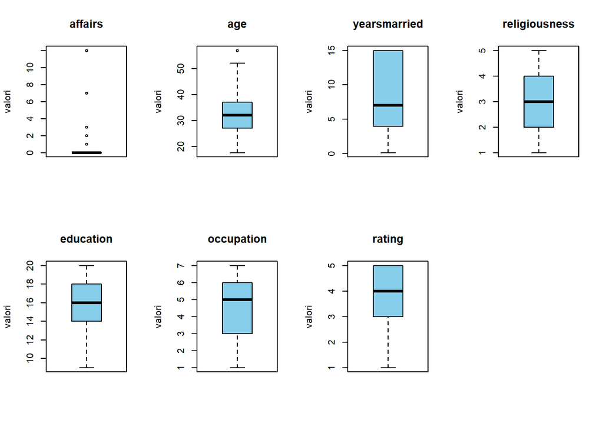

```r
par(mfrow= c(2,4))
for (col in names(Affairs)){
  if (is.numeric(Affairs[[col]])) {
    boxplot(Affairs[[col]], main = col,ylab = "valori" , col = "skyblue")}}
```

Passiamo ad un’altra distribuzione grafica delle variabili, i loro relativi **istogrammi**

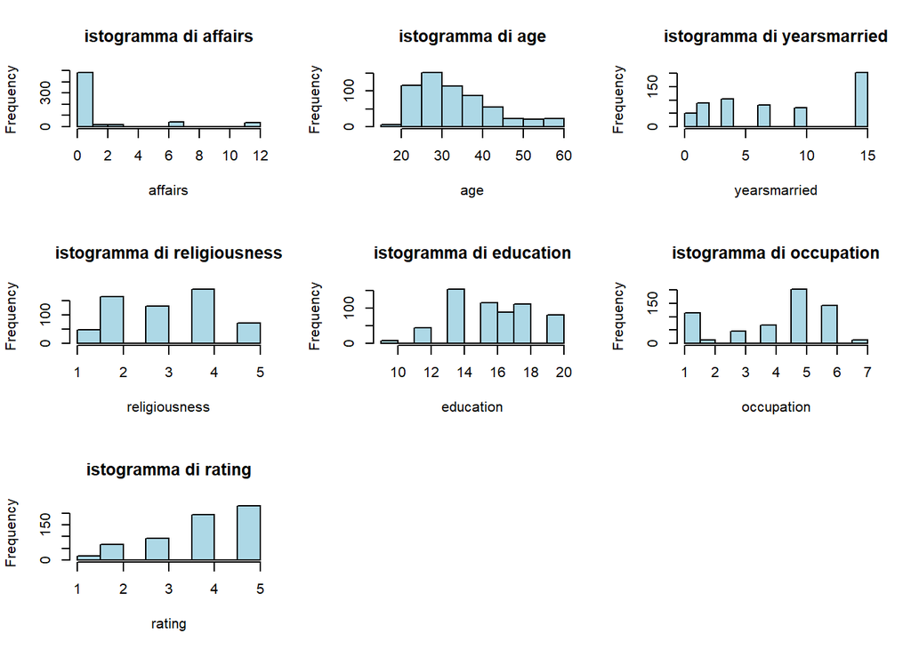

```r
par(mfrow= c (3,3))
for (col in names(Affairs)) {
  if (is.numeric(Affairs[[col]])) {
    hist(Affairs[[col]], main = paste("istogramma di", col),
         xlab = col,col="lightblue",border = "black")}}
```

Si può notare che sia dai boxplot e che (in parte) dai singoli istogrammi, ci siano degli outliers. Per cui, procediamo con la **eliminazione degli outliers** utilizzando il **metodo IQR** (Interquantile Range):

```r
# Funzione per identificare gli outlier usando l'IQR
identify_outliers <- function(data, variable) {
  Q1 <- quantile(data[[variable]], 0.18)
  Q3 <- quantile(data[[variable]], 0.82)
  IQR <- Q3 - Q1
  lower_bound <- Q1 - 1.5 * IQR
  upper_bound <- Q3 + 1.5 * IQR
  return(data[[variable]] < lower_bound | data[[variable]] > upper_bound)
}
```

```r
# Identificare e rimuovere gli outlier nel dataset
outlier_indices <- sapply(names(Affairs), function(var) {
  if (is.numeric(Affairs[[var]])) {identify_outliers(Affairs, var)} else {rep(FALSE, nrow(Affairs))}})
outlier_indices <- rowSums(outlier_indices) > 0
Affairs_clean <- Affairs[!outlier_indices, ]

# Verifica delle dimensioni del dataset pulito
dim(Affairs_clean)
```

```
## [1] 521   9
```

Per ottenere, invece, una rappresentazione grafica del modello “pulito”, possiamo creare il relativo **istogramma senza outliers**:

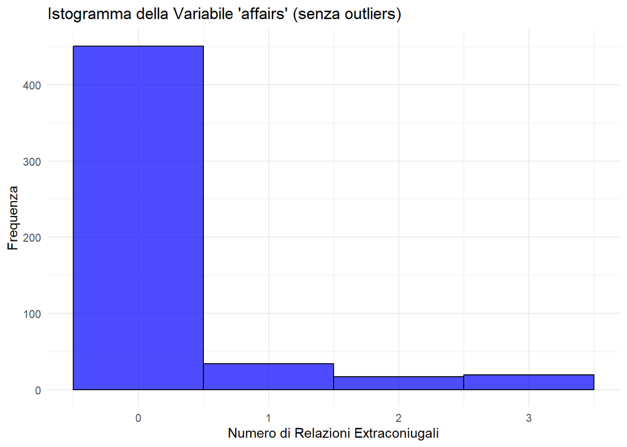

```r
# Istogramma senza outliers
library(ggplot2)
ggplot(Affairs_clean, aes(x=affairs)) +
  geom_histogram(binwidth = 1, fill = "blue", color = "black", alpha = 0.7) +
  labs(title = "Istogramma della Variabile 'affairs' (senza outliers) ",
       x = "Numero di Relazioni Extraconiugali", y = "Frequenza") +   theme_minimal()
```

```r
dim(Affairs_clean)
```

```
## [1] 521   9
```

```r
table(Affairs_clean$affairs)
```

```
##
##   0   1   2   3
## 451  34  17  19
```

Evidenziamo la netta differenza con l’**istogramma** della variavile “affair” ma con gli outliers:

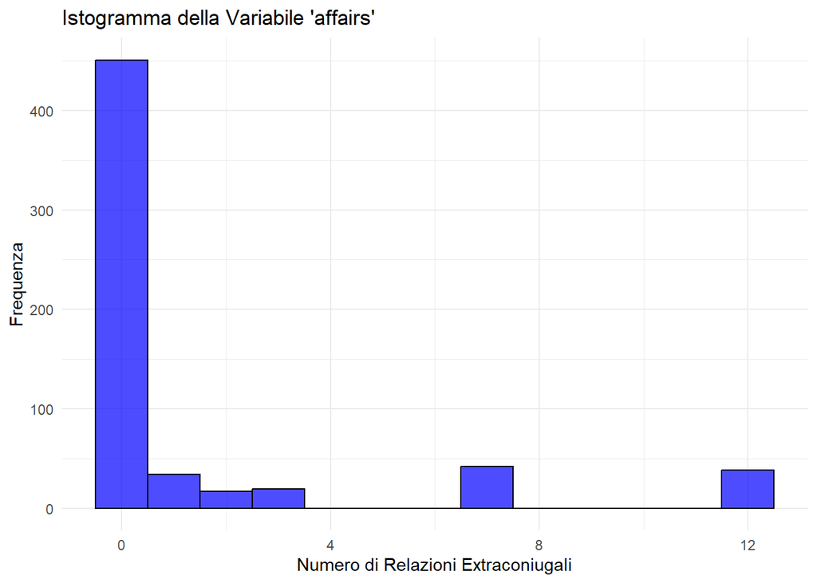

```r
library(ggplot2)
ggplot(Affairs, aes(x=affairs)) +
  geom_histogram(binwidth = 1, fill = "blue", color = "black", alpha = 0.7) +
  labs(title = "Istogramma della Variabile 'affairs' ", x = "Numero di Relazioni Extraconiugali", y = "Frequenza") +
  theme_minimal()
```

```r
dim(Affairs)
```

```
## [1] 601   9
```

```r
table(Affairs$affairs)
```

```
##
##   0   1   2   3   7  12
## 451  34  17  19  42  38
```

Dopodichè possiamo rifare i passaggi e analisi sulle variabili ma anche’esse senza outliers:

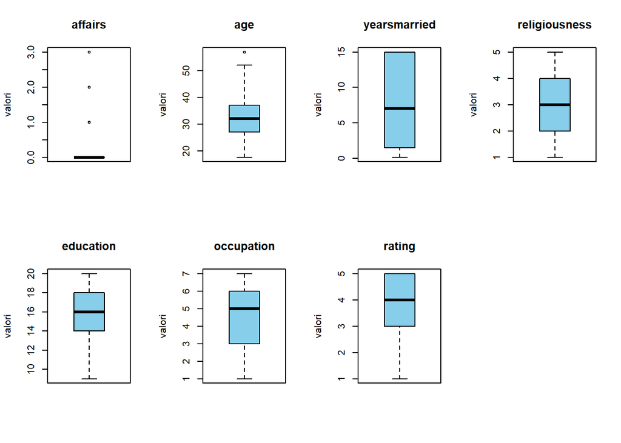

```r
par(mfrow= c(2,4))
for (col in names(Affairs_clean)){
  if (is.numeric(Affairs_clean[[col]])) {
    boxplot(Affairs_clean[[col]], main = col,ylab = "valori" , col = "skyblue")}}
```

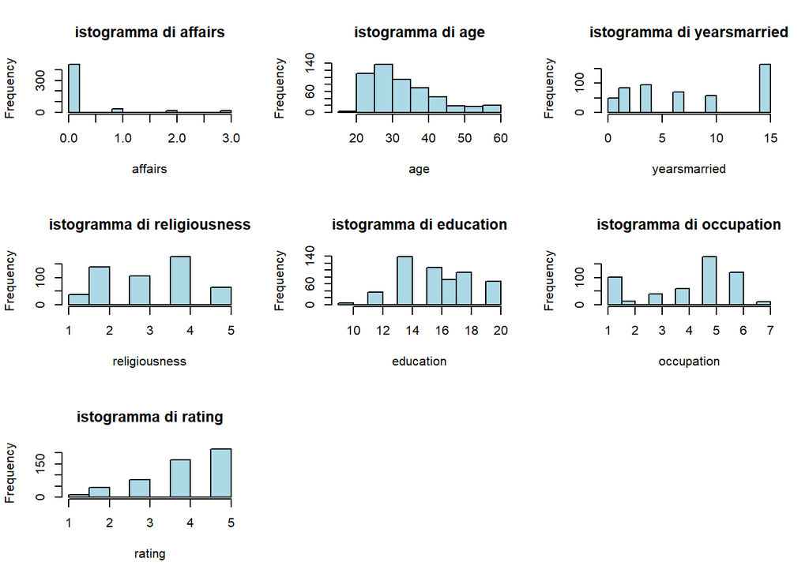

```r
par(mfrow= c (3,3))
for (col in names(Affairs_clean)) {
  if (is.numeric(Affairs_clean[[col]])) {
    hist(Affairs_clean[[col]], main = paste("istogramma di", col),
         xlab = col,col="lightblue",border = "black")}}
```

Infine, creiamo una **Tabella di correlazione**:

```r
continuous_vars <- c("age", "yearsmarried", "religiousness", "education", "occupation", "rating")
library(knitr)
```

```r
library(corrplot)
cor_table <- cor(Affairs_clean[continuous_vars])
kable(cor_table[,1])
```

|  | x |
| --- | --- |
| age | 1.0000000 |
| yearsmarried | 0.7823775 |
| religiousness | 0.2039133 |
| education | 0.1185868 |
| occupation | 0.1788957 |
| rating | -0.2059429 |

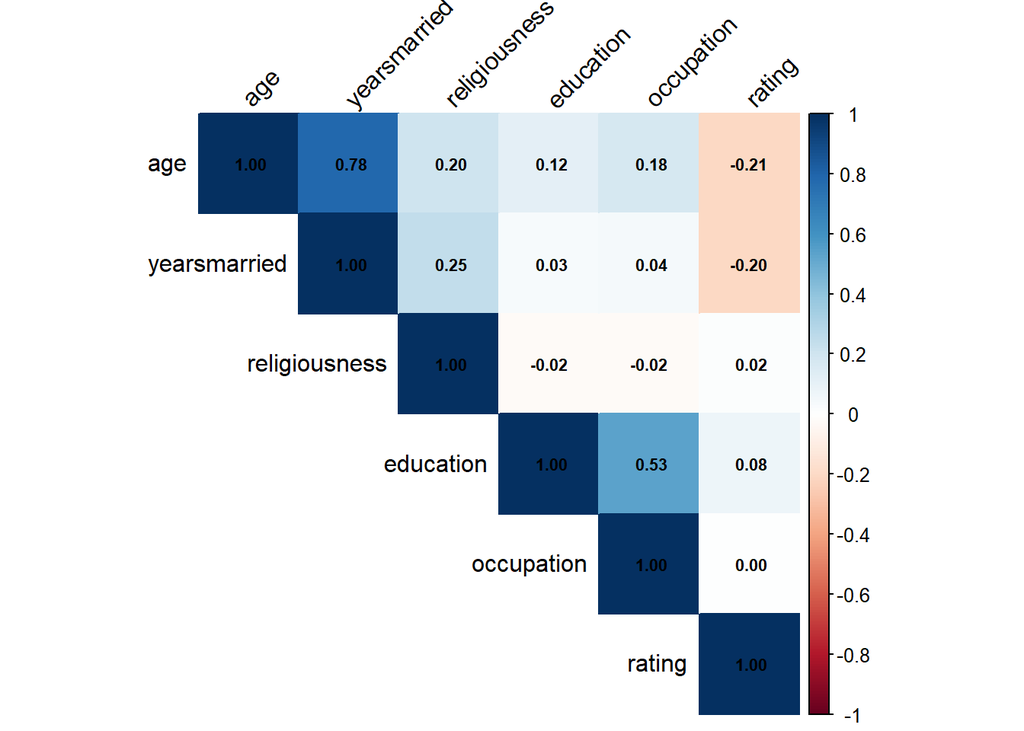

```r
corrplot(cor_table, method = "color", type = "upper", tl.col = "black", tl.srt = 45, addCoef.col = "black", number.cex = 0.7)
```

## **REGRESSIONE**

Infine, passiamo alla **Regressione**. Utilizzeremo un modello di regressione logistica:

$$logit(affairs) =\beta_0+\beta_1\cdot gender +\beta_2\cdot age
+\beta_3\cdot yearsmarried+\beta_4\cdot children +\beta_5\cdot
religiousness +\beta_6\cdot education +\beta_7\cdot occupation
+\beta_8\cdot rating$$

```r
# Aggiungiamo una variabile binaria per la regressione logistica
Affairs_clean$affair <- ifelse(Affairs_clean$affairs > 0, 1, 0)

# Visualizziamo la struttura del dataset
str(Affairs_clean)
```

```
## 'data.frame':    521 obs. of  10 variables:
##  $ affairs      : num  0 0 0 0 0 0 0 0 0 0 ...
##  $ gender       : Factor w/ 2 levels "female","male": 2 1 1 2 2 1 1 2 1 2 ...
##  $ age          : num  37 27 32 57 22 32 22 57 32 22 ...
##  $ yearsmarried : num  10 4 15 15 0.75 1.5 0.75 15 15 1.5 ...
##  $ children     : Factor w/ 2 levels "no","yes": 1 1 2 2 1 1 1 2 2 1 ...
##  $ religiousness: int  3 4 1 5 2 2 2 2 4 4 ...
##  $ education    : num  18 14 12 18 17 17 12 14 16 14 ...
##  $ occupation   : int  7 6 1 6 6 5 1 4 1 4 ...
##  $ rating       : int  4 4 4 5 3 5 3 4 2 5 ...
##  $ affair       : num  0 0 0 0 0 0 0 0 0 0 ...
```

```r
# Eseguiamo la regressione logistica
model <- glm(affair ~ gender + age + yearsmarried + children + religiousness + education + occupation + rating,
             family = binomial(link = "logit"),
             data = Affairs_clean)

# Sommario del modello
summary(model)
```

```
##
## Call:
## glm(formula = affair ~ gender + age + yearsmarried + children +
##     religiousness + education + occupation + rating, family = binomial(link = "logit"),
##     data = Affairs_clean)
##
## Coefficients:
##               Estimate Std. Error z value Pr(>|z|)
## (Intercept)    0.57376    1.19554   0.480  0.63128
## gendermale     0.65814    0.32381   2.032  0.04210 *
## age           -0.04638    0.02482  -1.868  0.06170 .
## yearsmarried   0.04180    0.04230   0.988  0.32303
## childrenyes    0.71559    0.38689   1.850  0.06437 .
## religiousness -0.15104    0.11754  -1.285  0.19879
## education     -0.01364    0.06672  -0.204  0.83805
## occupation    -0.02609    0.09621  -0.271  0.78622
## rating        -0.35110    0.12004  -2.925  0.00345 **
## ---
## Signif. codes:  0 '***' 0.001 '**' 0.01 '*' 0.05 '.' 0.1 ' ' 1
##
## (Dispersion parameter for binomial family taken to be 1)
##
##     Null deviance: 411.16  on 520  degrees of freedom
## Residual deviance: 388.74  on 512  degrees of freedom
## AIC: 406.74
##
## Number of Fisher Scoring iterations: 5
```

- **GENDER MALE**: questo 0.658 ci dice che essere maschio aumenta la probabilità di avere una relazione extraconiugale di 0.658 rispetto ad essere femmina, tenendo costanti tutti gli altri fattori.
- **AGE**: questo -0.046 ci dice che con l’aumento dell’età, la probabilità di avere una relazione extraconiugale diminuisce di 0.046 per ogni anno in più, tenendo costanti tutti gli altri fattori.
- **CHILDREN YES**: questo 0.716 ci dice che avere figli aumenta la probabilità di avere una relazione extraconiugale di 0.716 rispetto a non avere figli, tenendo costanti tutti gli altri fattori.
- **RATING**: questo -0.351 ci dice che con l’aumento del punteggio di soddisfazione matrimoniale, la probabilità di avere una relazione extraconiugale diminuisce di 0.351 per ogni punto aggiuntivo nella valutazione, tenendo costanti tutti gli altri fattori.

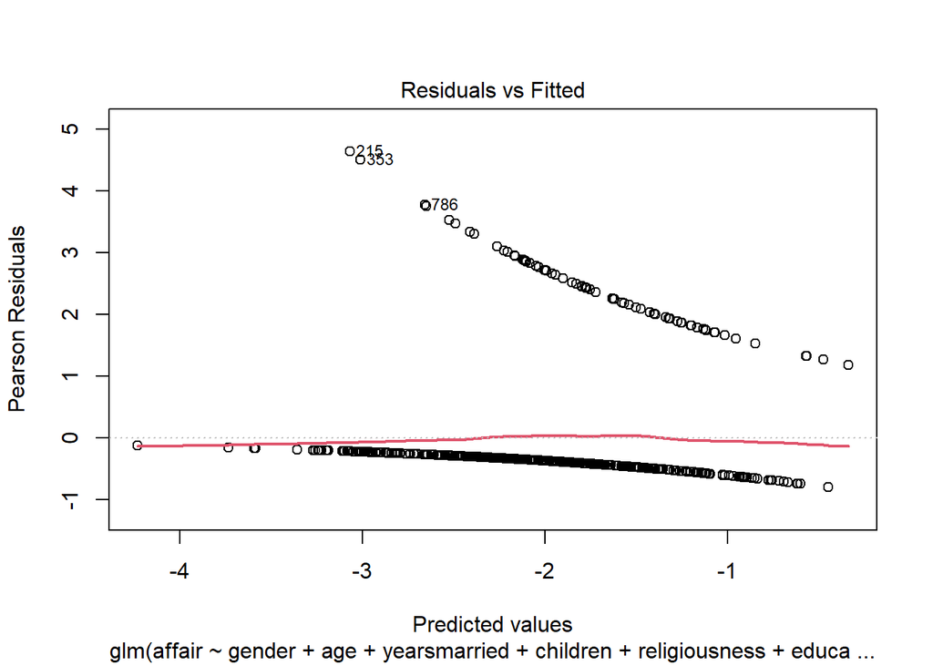

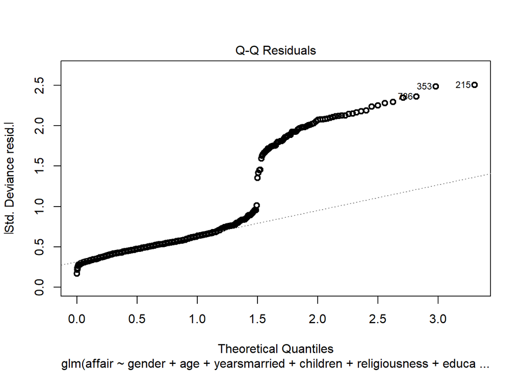

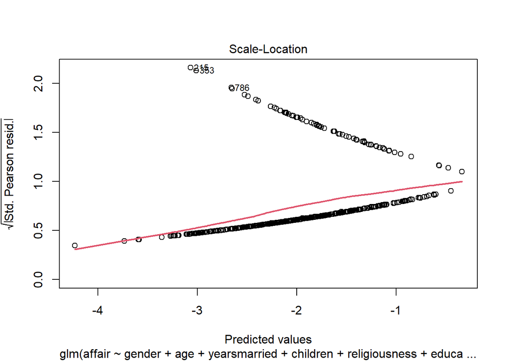

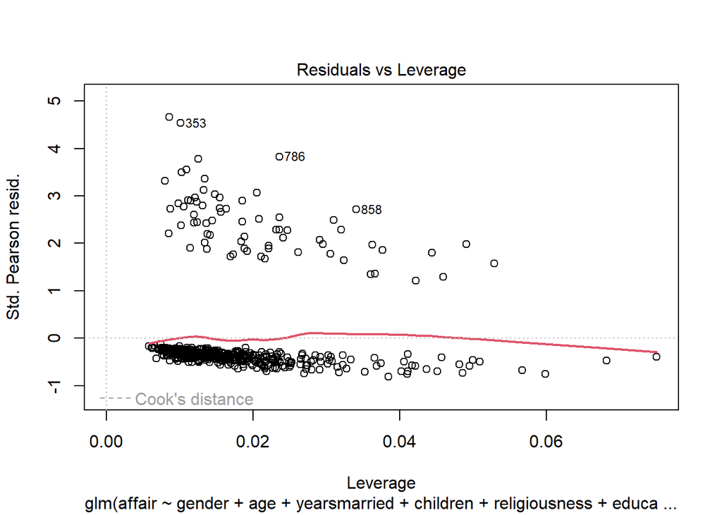

```r
#visualizziamo graficamente il modello realizzato
plot(model, lwd=2)
```

#### **Omoschedasticità o Eteroschedasticità ?**

Osserviamo dai grafici come il primo modello (model) sembrerebbe non adattarsi del tutto bene ai dati.

Per cui, rifacciamo la stessa regressione MA decidiamo di usare solo le **variabili significative**, anche se evidentemente “poco” significative:

**REGRESSIONE LOGISTICA SEMPLIFICATA**

$$logit(affairs) =\beta_0+\beta_1\cdot gender +\beta_2\cdot age
+\beta_3\cdot children +\beta_4\cdot rating$$

```r
#Regressione solo con variabili significative
model2 <- glm(affair ~ gender + age + children + rating,
             family = binomial(link = "logit"),
             data = Affairs_clean)
summary(model2)
```

```
##
## Call:
## glm(formula = affair ~ gender + age + children + rating, family = binomial(link = "logit"),
##     data = Affairs_clean)
##
## Coefficients:
##             Estimate Std. Error z value Pr(>|z|)
## (Intercept) -0.27712    0.74242  -0.373  0.70895
## gendermale   0.53551    0.26874   1.993  0.04630 *
## age         -0.03338    0.01659  -2.012  0.04425 *
## childrenyes  0.84726    0.35254   2.403  0.01625 *
## rating      -0.36723    0.11878  -3.092  0.00199 **
## ---
## Signif. codes:  0 '***' 0.001 '**' 0.01 '*' 0.05 '.' 0.1 ' ' 1
##
## (Dispersion parameter for binomial family taken to be 1)
##
##     Null deviance: 411.16  on 520  degrees of freedom
## Residual deviance: 391.21  on 516  degrees of freedom
## AIC: 401.21
##
## Number of Fisher Scoring iterations: 5
```

- **GENDER MALE**: questo 0.536 ci dice che essere maschio aumenta la probabilità di avere una relazione extraconiugale di 0.536 rispetto ad essere femmina, tenendo costanti tutti gli altri fattori.
- **AGE**: questo -0.033 ci dice che con l’aumento dell’età, la probabilità di avere una relazione extraconiugale diminuisce di 0.033 per ogni anno in più, tenendo costanti tutti gli altri fattori.
- **CHILDREN YES**: questo 0.847 ci dice che avere figli aumenta la probabilità di avere una relazione extraconiugale di 0.847 rispetto a non avere figli, tenendo costanti tutti gli altri fattori.
- **RATING**: questo -0.367 ci dice che con l’aumento del punteggio di soddisfazione matrimoniale, la probabilità di avere una relazione extraconiugale diminuisce di 0.367 per ogni punto aggiuntivo nella valutazione, tenendo costanti tutti gli altri fattori.

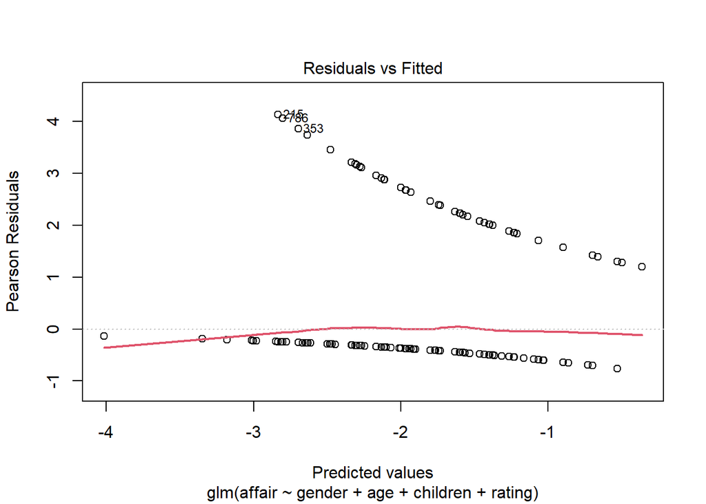

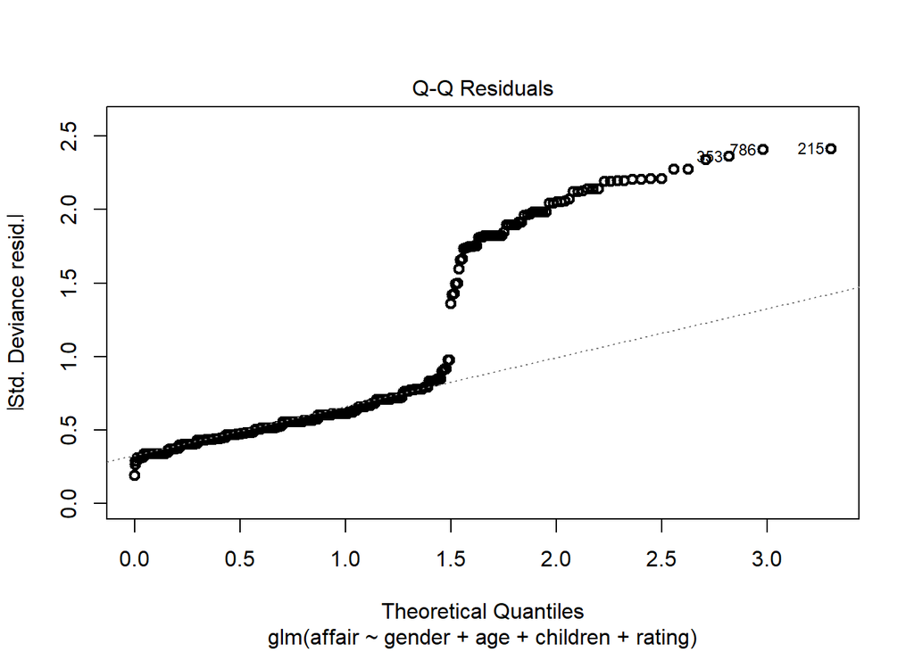

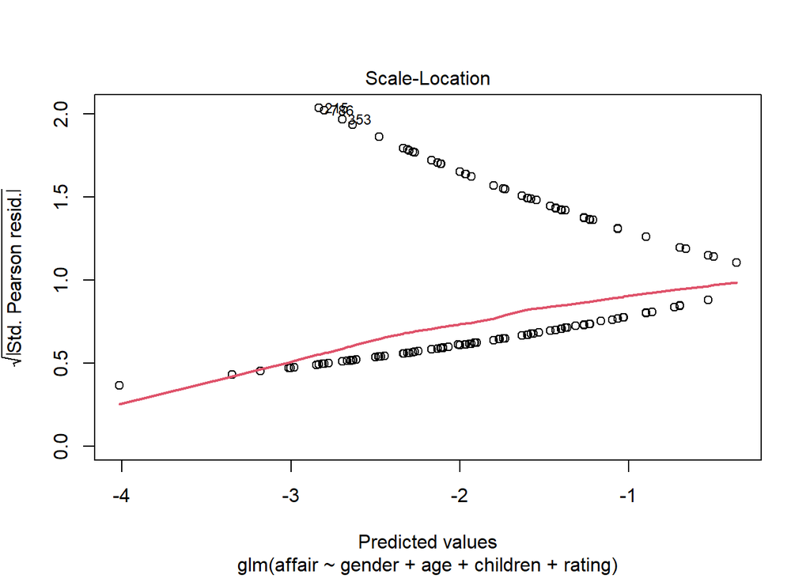

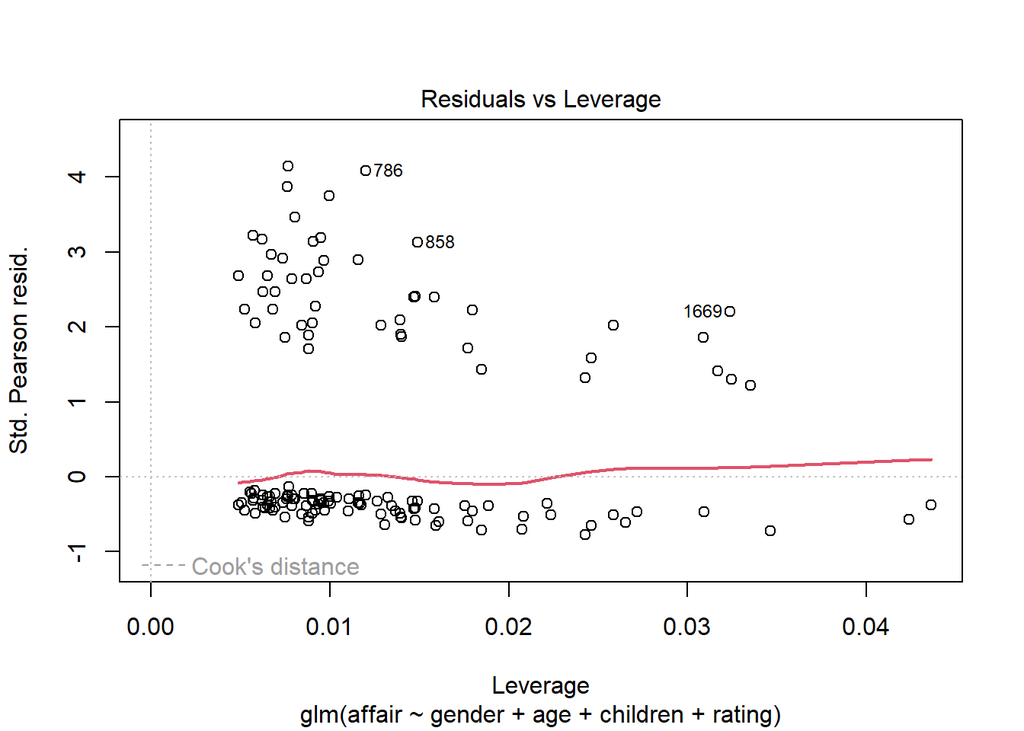

```r
plot(model2, lwd=2)
```

Nonostante la semplificazione del modello, osserviamo da questi grafici come vi sia ancora una forte presenza di outliers che il modello non riesce a catturare. Proviamo ad introdurre un **termine d’interazione** e confrontiamo i risultati:

```r
#Regressione logistica con termine d'interazione
model2_interaction <- glm(affair ~ gender + children + rating * age,
             family = binomial(link = "logit"),
             data = Affairs_clean)
summary(model2_interaction)
```

```
##
## Call:
## glm(formula = affair ~ gender + children + rating * age, family = binomial(link = "logit"),
##     data = Affairs_clean)
##
## Coefficients:
##             Estimate Std. Error z value Pr(>|z|)
## (Intercept)  1.77529    1.77309   1.001   0.3167
## gendermale   0.52756    0.26977   1.956   0.0505 .
## childrenyes  0.80153    0.35543   2.255   0.0241 *
## rating      -0.91953    0.44639  -2.060   0.0394 *
## age         -0.09437    0.05201  -1.814   0.0696 .
## rating:age   0.01694    0.01328   1.275   0.2021
## ---
## Signif. codes:  0 '***' 0.001 '**' 0.01 '*' 0.05 '.' 0.1 ' ' 1
##
## (Dispersion parameter for binomial family taken to be 1)
##
##     Null deviance: 411.16  on 520  degrees of freedom
## Residual deviance: 389.50  on 515  degrees of freedom
## AIC: 401.5
##
## Number of Fisher Scoring iterations: 5
```

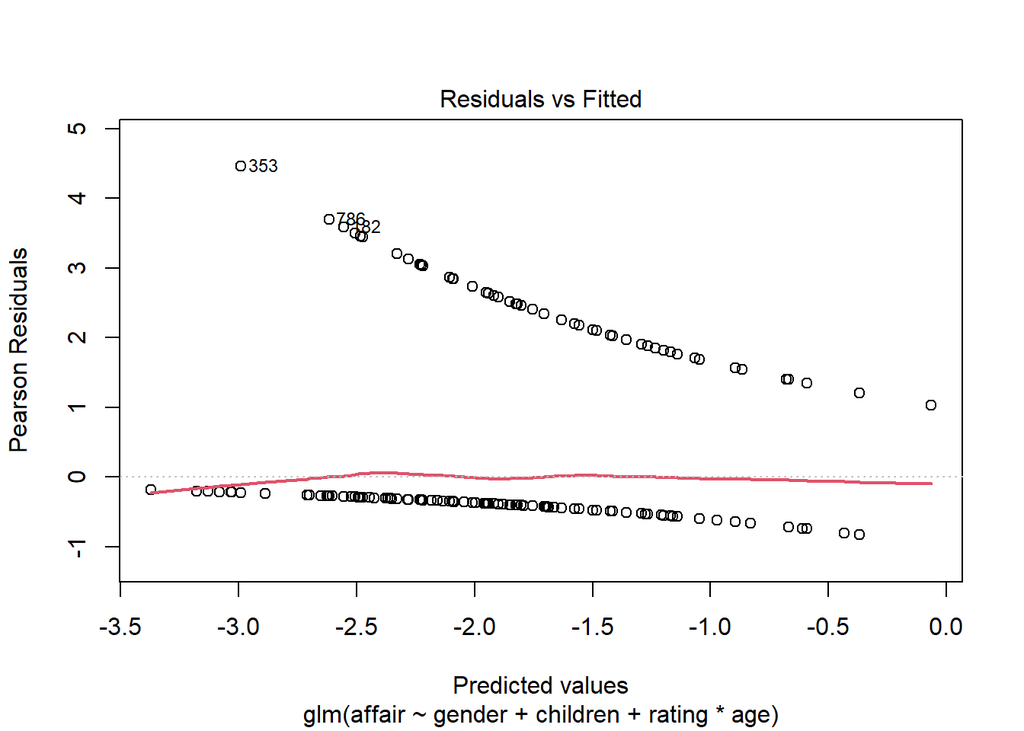

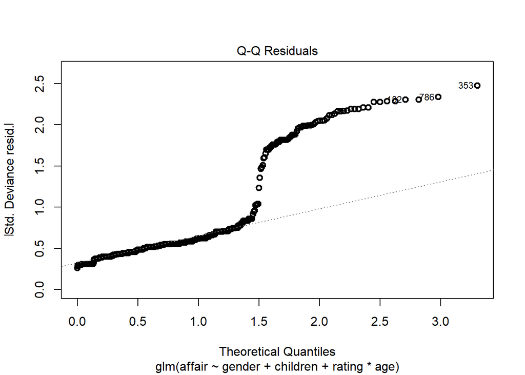

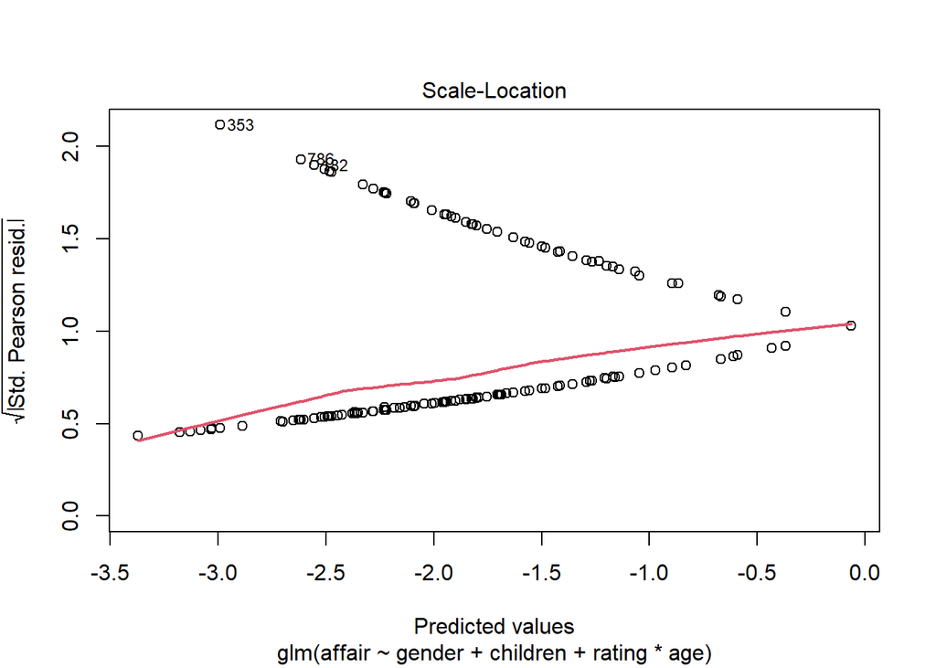

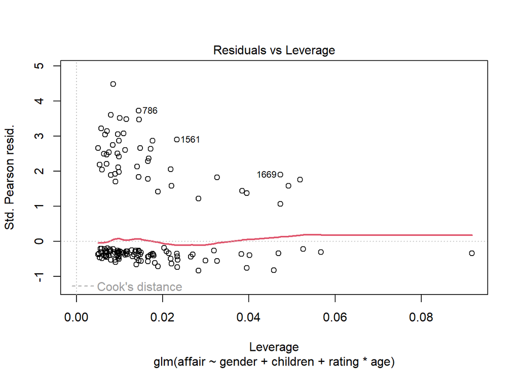

```r
plot(model2_interaction, lwd =2)
```

Anche con questo modello non siamo riusciti ad eliminare questi valori critici… una possibile causa potrebbe essere il non aver incluso nello studio effettuato variabili importanti che influenzano fortemente “affair”.

Creiamo un **grafico a dispersione** fra la Y = “affair” e la X = “rating”.

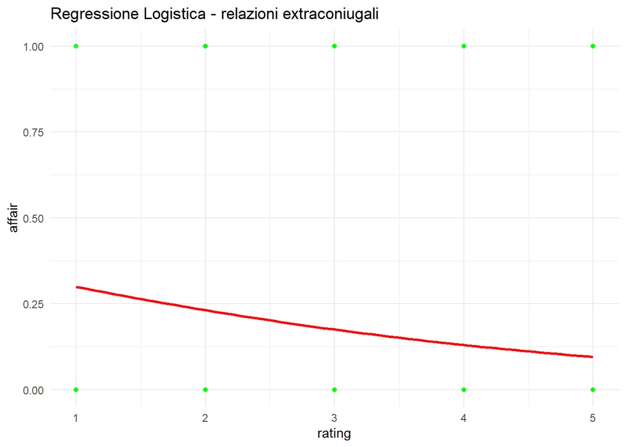

```r
library(ggplot2)
ggplot(Affairs_clean, aes(x = rating , y = affair)) +
  geom_point(alpha = 0.5, color = "green") +  # Punti di dispersione con trasparenza
  geom_smooth(method = "glm", method.args = list(family = "binomial"), se = FALSE, color = "red") +  # Curva di regressione logistica senza intervallo di confidenza
  labs(title = "Regressione Logistica - relazioni extraconiugali",
       x = "rating",
       y = "affair") + theme_minimal()
```

Dopodichè, ci soffermiamo su un’analisi più approfondita dei **Residui**

```r
# Estrazione dei residui
residuals_clean<-residuals(model2_interaction)
```

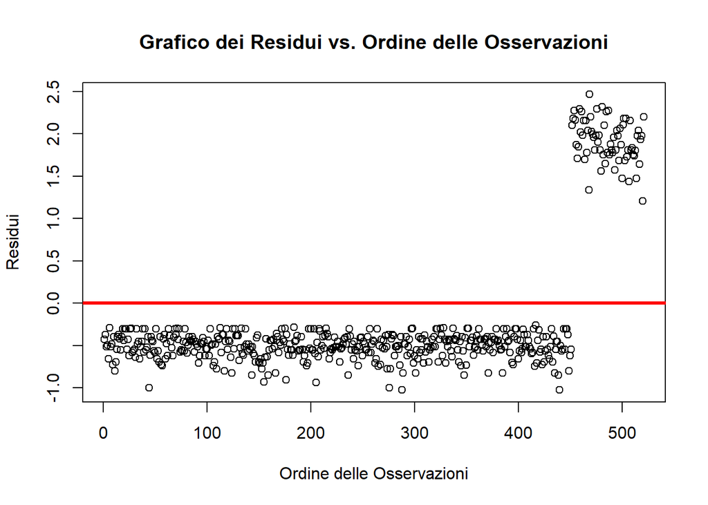

```r
# Grafico dei Residui vs. Ordine delle Osservazioni
plot(residuals_clean, type = "p", main = "Grafico dei Residui vs. Ordine delle Osservazioni", ylab = "Residui", xlab = "Ordine delle Osservazioni")
abline(h = 0, col="red",lwd=3)
```

## **PCA**

*Matrice scatterplot*

1. Caricamento delle librerie necessarie

```r
library(dplyr)
library(GGally)
```

```r
library(ggplot2)
```

2. Visualizzazione della struttura del dataset Affairs

```r
str(Affairs)
```

```
## 'data.frame':    601 obs. of  9 variables:
##  $ affairs      : num  0 0 0 0 0 0 0 0 0 0 ...
##  $ gender       : Factor w/ 2 levels "female","male": 2 1 1 2 2 1 1 2 1 2 ...
##  $ age          : num  37 27 32 57 22 32 22 57 32 22 ...
##  $ yearsmarried : num  10 4 15 15 0.75 1.5 0.75 15 15 1.5 ...
##  $ children     : Factor w/ 2 levels "no","yes": 1 1 2 2 1 1 1 2 2 1 ...
##  $ religiousness: int  3 4 1 5 2 2 2 2 4 4 ...
##  $ education    : num  18 14 12 18 17 17 12 14 16 14 ...
##  $ occupation   : int  7 6 1 6 6 5 1 4 1 4 ...
##  $ rating       : int  4 4 4 5 3 5 3 4 2 5 ...
```

3. Selezione delle variabili numeriche dal dataset Affairs

```r
dati_reg_no_dummy <- dplyr::select(Affairs, age, yearsmarried, religiousness, education, occupation, rating, affairs)
```

4. Controllo della struttura dei dati selezionati

```r
class(dati_reg_no_dummy) <- "data.frame"
```

5. Creazione della matrice scatterplot

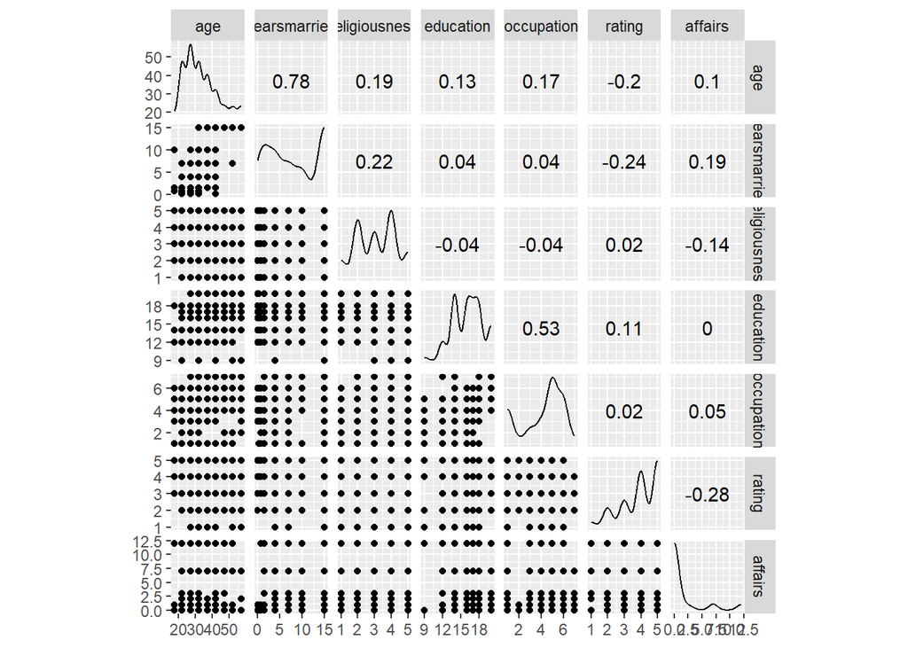

```r
ggscatmat(dati_reg_no_dummy)
```

*Standardizzazione dei dati e analisi PCA*

1. Esecuzione dell’analisi PCA

```r
PCA2 <- princomp(dati_reg_no_dummy, cor = TRUE)
```

2. Visualizzazione del sommario della PCA con i loadings

```r
print(summary(PCA2, loadings = TRUE), cutoff = .3)
```

```
## Importance of components:
##                           Comp.1    Comp.2    Comp.3    Comp.4     Comp.5
## Standard deviation     1.4339476 1.2444559 1.1301189 0.8713945 0.83305652
## Proportion of Variance 0.2937437 0.2212387 0.1824527 0.1084755 0.09914045
## Cumulative Proportion  0.2937437 0.5149823 0.6974350 0.8059105 0.90505092
##                            Comp.6     Comp.7
## Standard deviation     0.67734638 0.45370189
## Proportion of Variance 0.06554259 0.02940649
## Cumulative Proportion  0.97059351 1.00000000
##
## Loadings:
##               Comp.1 Comp.2 Comp.3 Comp.4 Comp.5 Comp.6 Comp.7
## age            0.616                0.318                0.693
## yearsmarried   0.615                                    -0.706
## religiousness                0.603 -0.707
## education            -0.673                      -0.716
## occupation           -0.641                       0.681
## rating                       0.431  0.489 -0.625
## affairs                     -0.626        -0.715
```

*Correlazione variabili e componenti principali*

1. Caricamento della libreria ggplot2

```r
library(ggplot2)
```

2. Calcolo e visualizzazione dell matrice di correlazione

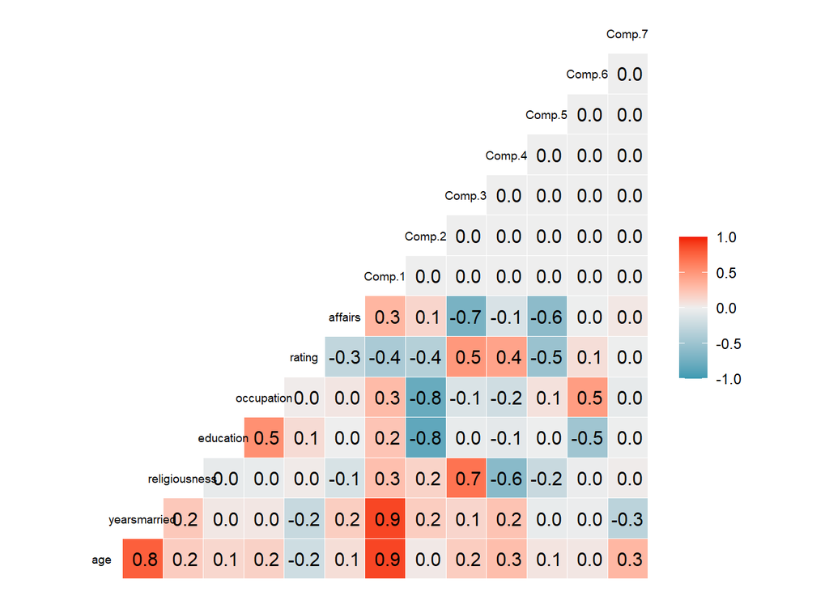

```r
ggcorr(cbind(dati_reg_no_dummy, PCA2$scores), label = TRUE, cex = 2.5)
```

*Visualizzazione PCA*

1. Caricamento delle librerie FactoMineR e factoextra

```r
suppressPackageStartupMessages(library(FactoMineR))
suppressPackageStartupMessages(library(factoextra))
```

2. Scree plot delle componenti principali

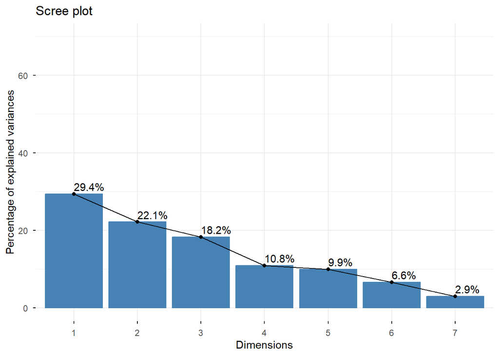

```r
fviz_eig(PCA2, addlabels = TRUE, ylim = c(0, 70))
```

3. Visualizzazione degli individui nella PCA

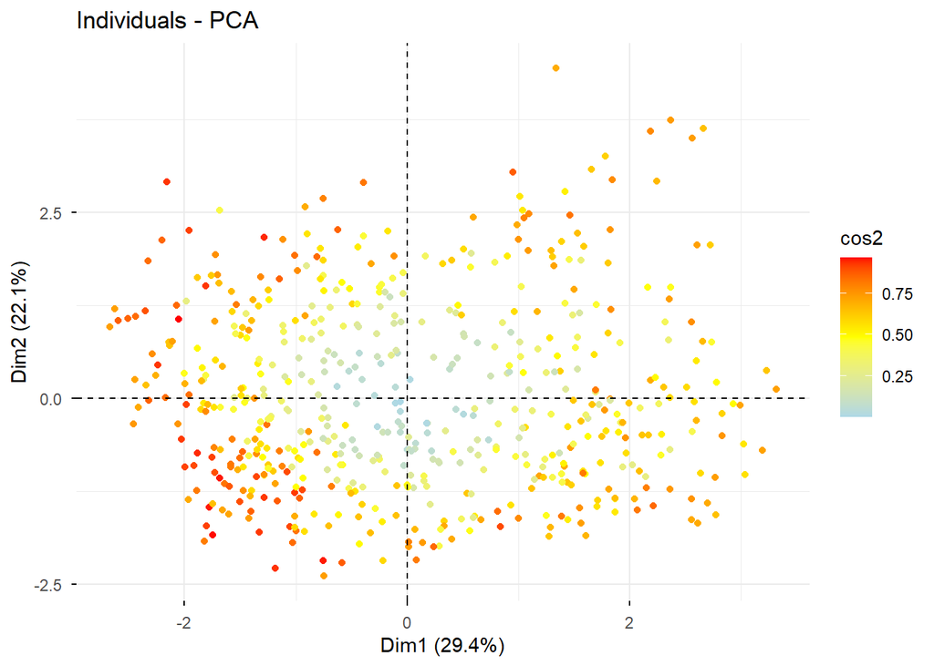

```r
fviz_pca_ind(PCA2,
             axes = c(1, 2),
             col.ind = "cos2", # Colore per la qualità della rappresentazione
             gradient.cols = c("lightblue", "yellow", "red"),
             repel = TRUE,
             label = TRUE)
```

4. Visualizzazione delle variabili nella PCA

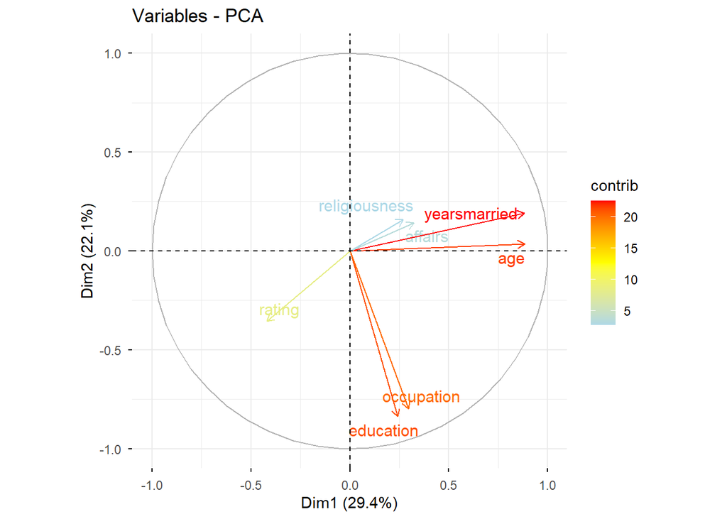

```r
fviz_pca_var(PCA2,
             axes = c(1, 2),
             col.var = "contrib", # Colore per contributi alle PC
             gradient.cols = c("lightblue", "yellow", "red"),
             repel = TRUE) # Evita la sovrapposizione del testo
```

5. Biplot delle variabili e degli individui nella PCA

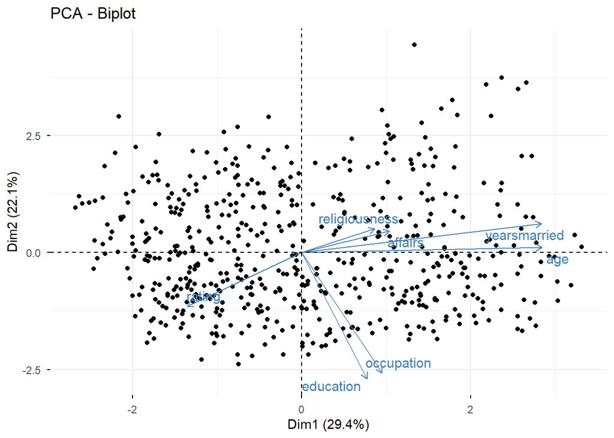

```r
fviz_pca_biplot(PCA2, axes = c(1, 2),
                label = "var",
                repel = TRUE,
                geom.ind = "point",
                label.ind = FALSE)
```

6. Creazione del biplot delle prime due componenti principali

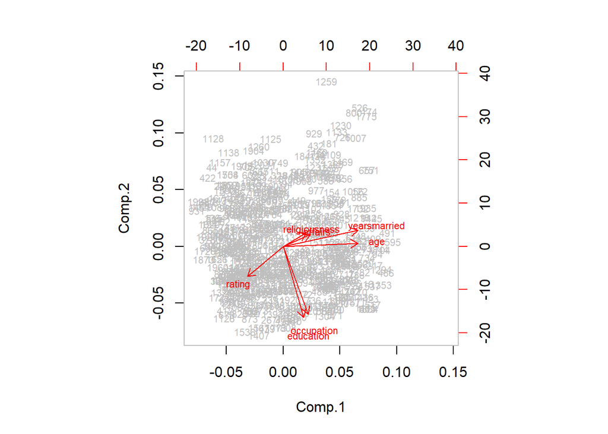

```r
biplot(PCA2, choices = c(1, 2), cex = c(.7, .7), col = c("gray", "red"))
```

## *Cluster analisi*

**Configurazione dell’ambiente**

```r
library(stats)
suppressPackageStartupMessages(library(factoextra))
library(cluster)
```

**Preparazione dei dati**

```r
# Selezione delle colonne per il clustering
vars <- Affairs[, c("age", "yearsmarried", "religiousness", "rating", "education", "occupation","children", "gender")]

# Conversione di children e gender in variabili dummy
vars$children <- as.factor(vars$children)
vars$gender <- as.factor(vars$gender)

# Creazione di variabili dummy
vars_dummy <- model.matrix(~ . - 1, data = vars)

# Esecuzione della PCA
pca_result <- prcomp(vars_dummy, scale. = TRUE)
summary(pca_result)
```

```
## Importance of components:
##                          PC1    PC2    PC3    PC4     PC5    PC6     PC7    PC8
## Standard deviation     1.747 1.4099 1.0189 0.9840 0.86983 0.7625 0.65610 0.4317
## Proportion of Variance 0.339 0.2208 0.1154 0.1076 0.08407 0.0646 0.04783 0.0207
## Cumulative Proportion  0.339 0.5599 0.6752 0.7828 0.86687 0.9315 0.97930 1.0000
##                              PC9
## Standard deviation     1.909e-16
## Proportion of Variance 0.000e+00
## Cumulative Proportion  1.000e+00
```

```r
# Estrazione delle prime due componenti principali
pca_data <- pca_result$x[, 1:2]
```

**Determinazione del numero ottimale di cluster**

```r
# Funzione di Calcolo del Punteggio di Silhouette
silhouette_score <- function(k){
  km <- kmeans(pca_data, centers = k, nstart = 25)
  ss <- silhouette(km$cluster, dist(pca_data))
  mean(ss[, 3])}

# Definizione del Range di Cluster da Valutare
k_values <- 2:10

# Calcolo dei Punteggi di Silhouette per Ogni K
avg_silhouette <- sapply(k_values, silhouette_score)

# Identificazione del Numero Ottimale di Cluster
optimal_k <- k_values[which.max(avg_silhouette)]
```

**Visualizzazione dei risultati**

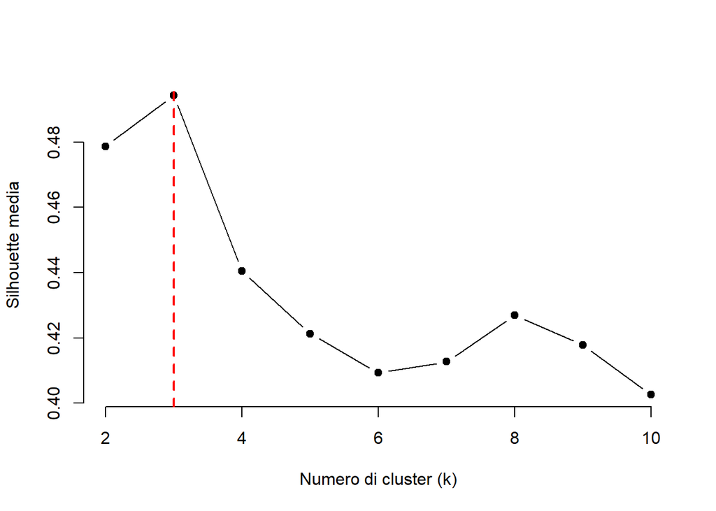

```r
# Visualizzazione Grafica dei Punteggi di Silhouette
plot(k_values, avg_silhouette, type = "b", pch = 19, frame = FALSE,
     xlab = "Numero di cluster (k)", ylab = "Silhouette media")

# Marcatura del K Ottimale sul Grafico
abline(v = optimal_k, lty = 2, col = "red", lwd=2)
```

**Esecuzione e visualizzazione del cluster k-means**

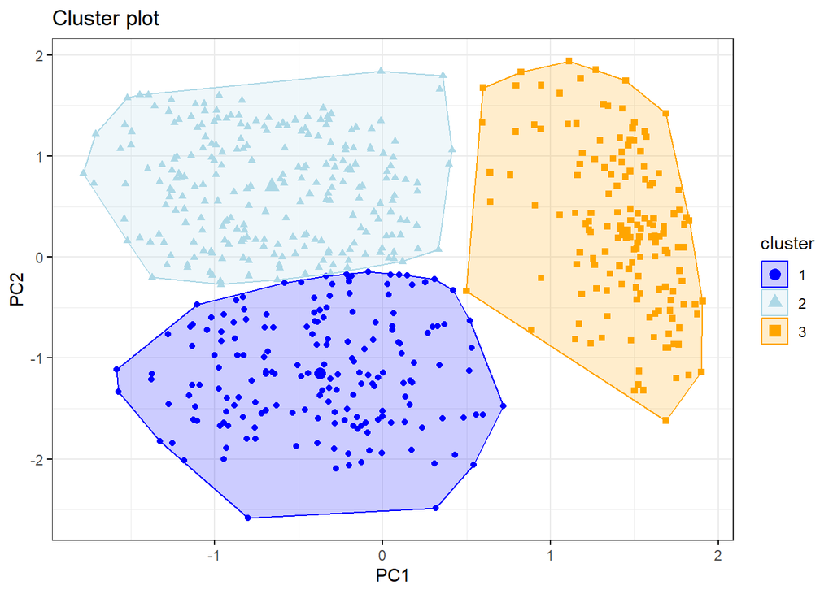

```r
# Imposta il seme per la riproducibilità
set.seed(123)

# Esecuzione dell'algoritmo K-means
km_result <- kmeans(pca_data, centers = optimal_k, nstart = 25)

# Visualizzazione dei cluster
fviz_cluster(km_result, data = pca_data,
             palette = c("blue", "lightblue", "orange", "red", "brown"),
             geom = "point",
             ellipse.type = "convex",
             ggtheme = theme_bw())
```

**Valutazione della qualità del clustering**

```
##   cluster size ave.sil.width
## 1       1  187          0.46
## 2       2  251          0.46
## 3       3  163          0.59
```

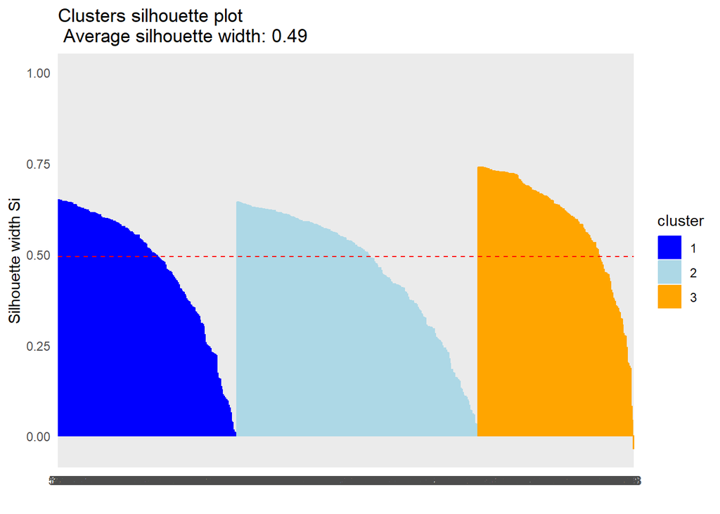

```r
# Calcolo e visualizzazione del plot della silhouette
sil <- silhouette(km_result$cluster, dist(pca_data))
fviz_silhouette(sil,palette= c("blue","lightblue","orange")) + theme_minimal()
```

**Calcolo e visualizzazione delle medie delle variabili per ciascun Cluster**

```r
# Assegnazione dei cluster alle osservazioni
cluster_assignments <- km_result$cluster

# Aggiunta dell'assegnazione del cluster al dataset originale
clustered_data <- cbind(vars, cluster = cluster_assignments)

# Calcolo delle medie delle variabili per ciascun cluster
cluster_means <- aggregate(. ~ cluster, data = clustered_data, FUN = mean)

# Visualizzazione delle medie delle variabili per ciascun cluster
print(cluster_means)
```

```
##   cluster      age yearsmarried religiousness   rating education occupation
## 1       1 32.32620     9.540556      3.294118 3.668449  14.24064   2.395722
## 2       2 37.36056    10.846781      3.167331 3.876494  17.60159   5.398406
## 3       3 25.16871     2.504104      2.834356 4.319018  16.16564   4.404908
##   children   gender
## 1 1.994652 1.101604
## 2 1.968127 1.800797
## 3 1.006135 1.404908
```

**Analisi delle Frequenze di Relazioni Extraconiugali per Cluster**

```r
# Aggiunta della variabile "affairs" al dataset
clustered_data <- cbind(clustered_data, affairs = Affairs$affairs)
# Calcolo delle frequenze di affair per ciascun cluster
affair_freq <- table(clustered_data$cluster, clustered_data$affairs == 1)
# Visualizzazione delle frequenze di affair per ciascun cluster
print(affair_freq)
```

```
##
##     FALSE TRUE
##   1   170   17
##   2   241   10
##   3   156    7
```

**Test del Chi-Quadrato su Frequenze di Relazioni Extraconiugali**

```r
# Test chi-quadrato
chi_sq_test <- chisq.test(affair_freq)
print(chi_sq_test)
```

```
##
##  Pearson's Chi-squared test
##
## data:  affair_freq
## X-squared = 6.0146, df = 2, p-value = 0.04942
```